# Week 3 Project

## Mira Ensley-Field

Compiled on Sat Feb 25 07:14:31 2017.

# Graphic 1.

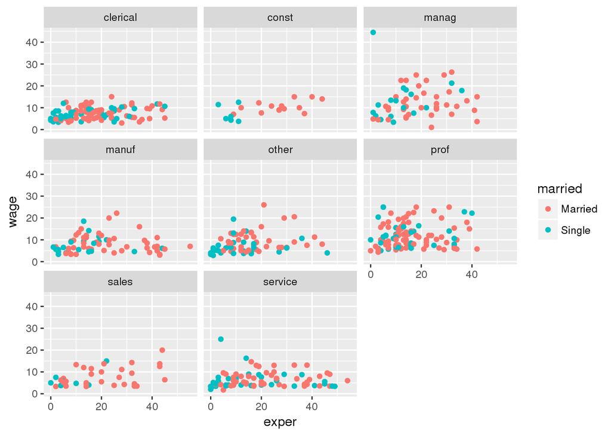

```r
ggplot(data = CPS85, aes(x = exper), y=wage) + geom_point(aes(x=exper,y=wage,color=married))  + facet_wrap(~sector)
```

What mode of graphic is it?

- this is a scatter plot (geom_point)

What variables from the respective data tables are involved?

- exper, married, wage, and sector are all involved

What role each of those variables plays in the graphic?

# Graphic 2

(I couldn’t get the graphic to match exactly)

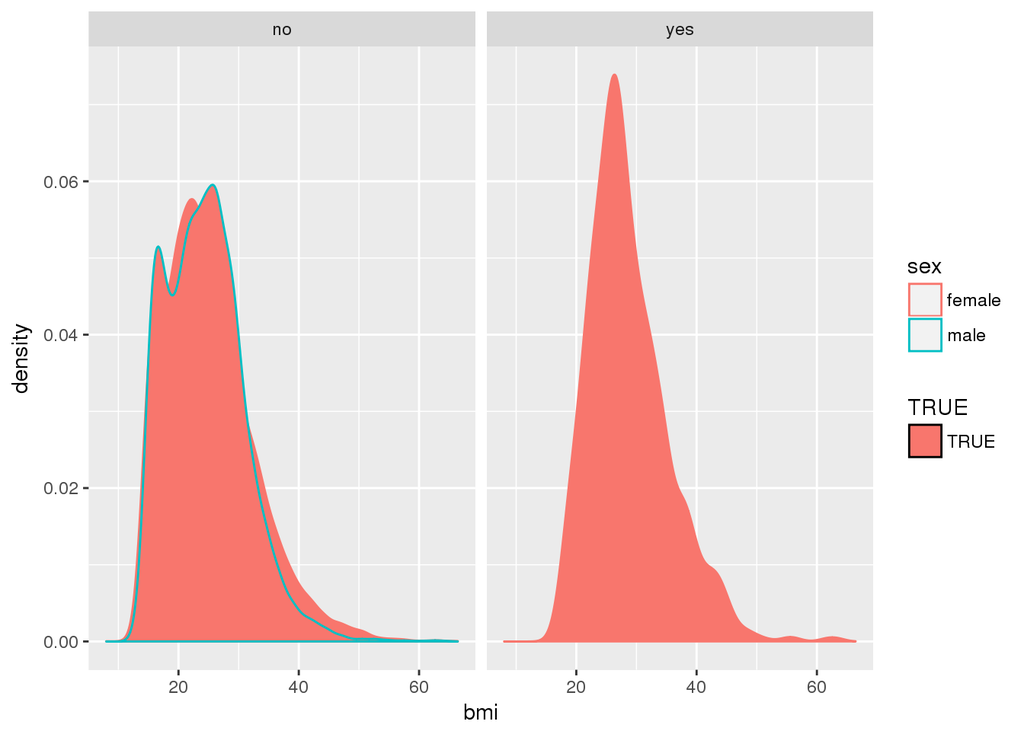

```r
ggplot(data = NCHS, aes(x = bmi)) + geom_density(aes(color=sex,fill=TRUE))+ facet_wrap(~pregnant)
```

What mode of graphic is it? (e.g. density plot, scatter plot, bar plot, …)

- density plot

What variables from the respective data tables are involved?

- sex, pregnant, bmi

What role each of those variables plays in the graphic?

In Figure 2, why is there no data variable being used for the y-axis?

- the frequency of that particular bmi is on the y axis

PLaying with graphs

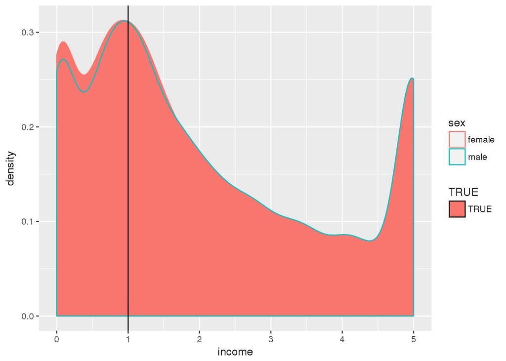

```r
ggplot(data = NCHS, aes(x = income), title="income distribution by sex and poverty line") + geom_density(aes(color=sex,fill=TRUE))  + geom_vline(xintercept=1,show.legend=TRUE)
```

# Wrangling

Which color diamonds seem to be largest on average (in terms of carats)?

```r
largest_diamonds_color<-
  diamonds %>%
  group_by(color) %>%
  summarise(size=mean(carat)) %>%
  arrange(-size)
```

the “j” color are the largest on average (1.1.6 carats)

```r
largest_clarity_table<-
  diamonds %>%
  group_by(clarity) %>%
  summarise(size=mean(table),weight=mean(carat)) %>%
  arrange(-size/weight)
```

# Voting

Using the Minneapolis2013 data table, answer these questions. summarise(), group_by(), and tally() will be useful in answering the questions.

How many cases are there? 80,101

```r
nrow(Minneapolis2013)
```

```
## [1] 80101
```

Who were the top 5 candidates in the Second vote selections.

```r
top_candidates <-
  Minneapolis2013 %>%
  group_by(Second) %>%
 summarise(seconds=count(Second)) %>%
  arrange(-seconds)

top_five_candidates<-head(top_candidates,6)
```

1 BETSY HODGES 14399

2 DON SAMUELS 14170

3 MARK ANDREW 12757

5 JACKIE CHERRYHOMES 6470

6 BOB FINE 3751

How many ballots are marked “undervote” inFirst choice selections?

834

```r
undervote_first <-
  Minneapolis2013 %>%
  group_by(First) %>%
  filter(First == "undervote") %>%
 summarise(votes=count(First))
```

Second choice selections?

10,598

```r
undervote_second <-
  Minneapolis2013 %>%
  group_by(Second) %>%
  filter(Second == "undervote") %>%
 summarise(votes=count(Second))
```

Third choice selections? 19,210

```r
undervote_third <-
  Minneapolis2013 %>%
  group_by(Third) %>%
  filter(Third == "undervote") %>%
 summarise(votes=count(Third))
```

What are the top 3 Second vote selections among people who voted for Betsy Hodges as their first choice?

1 MARK ANDREW 8787

2 DON SAMUELS 8743

3 JACKIE CHERRYHOMES 2563

```r
besty_supporters<-
  Minneapolis2013 %>%
  filter(First == "BETSY HODGES") %>%
  group_by(Second) %>%
  summarise(votes=count(Second)) %>%
  arrange(-votes)

besty_supporters_top3<-head(besty_supporters,3)
```

Which Precinct had the highest fraction of First vote selections marked as “undervote”? (To calculate the fraction, use mean(First == “undervote”) in the argument to summarise().)

P-05A

```r
high_undervote<-
  Minneapolis2013 %>%
  group_by(Precinct) %>%
  summarise(undervotes=count(First =="undervote"), total=count(First)) %>%
  arrange(-undervotes/total)
```